# Mark-Recapture Workshop 2024

Introduction to Mark-Recapture

Dr. Matthijs Hollanders

## Mark-recapture sampling

- Conduct multiple surveys for wildlife
- Every new animal gets a uniquely identifiable mark
- Some animals are recaptured some of the time
- *Time series*: everything we care about is informed by recaptures of individuals
- Parameters to be estimated: survival, recruitment, some dynamics, detection
- Derived quantities: population size

**Important**

Spatial capture-recapture (SCR) models are different from survey-based traditional models. Traditional models estimate survival between recaptures, whereas SCR models estimate population size or density directly.

## Hidden Markov Models

- Broad class of models that encompass a huge amount of ecological models
  - Mark-recapture, occupancy, *N*-mixture
- (Partially) unobserved *latent* process (time series)
  - Animals surviving or dying
- *Observation* process conditioned on this latent process
  - Animals getting detected or not

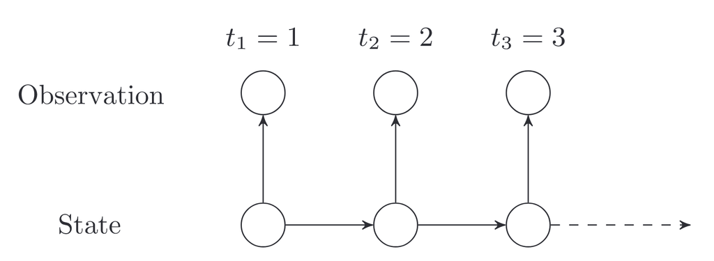

Glennie et al. (2023)

## Cormack-Jolly-Seber model

$$\begin{aligned}
z_{i,j} &\sim \mathrm{Bernoulli} ( z_{i,j-1} \cdot \phi ), \quad i \in 1:I, \ j \in (f_i + 1):J \\
y_{i,j} &\sim \mathrm{Bernoulli} ( z_{i,j} \cdot p) \\
\phi, p &\sim \mathrm{Beta}(1, 1)
\end{aligned}$$

- $z_{i,j}$: ecological state (1 = alive, 0 = dead) of individual $i$ at time $j$
- $y_{i,j}$: observed state (1 = observed, 0 = not observed) of individual $i$ at time $j$
- $f_i$: occasion (survey) of first capture (model *starts* here!)
- $\phi$: apparent survival probability
  - Probability of surviving from time $j-1$ to time $j$
- $p$: detection probability
  - Probability of detecting the individual if it is alive
- $\mathrm{Beta}(1, 1)$ is a uniform prior on [0,1]

## Mark-recapture yields *detection histories*

```r
# simulation input
I <- 100
J <- 9
f <- sample(1:J, I, replace = T) |> sort()
phi <- 0.7
p <- 0.3

# matrix of ecological and observed states
z <- y <- matrix(NA, I, J)
for (i in 1:I) {
  z[i, f[i]] <- y[i, f[i]] <- 1
  if (f[i] < J) {
    for (j in (f[i] + 1):J) {
      z[i, j] <- rbinom(1, 1, z[i, j - 1] * phi)
      y[i, j] <- rbinom(1, 1, z[i, j] * p)
    }
  }
}
```

```r
head(z, 6)
```

```
     [,1] [,2] [,3] [,4] [,5] [,6] [,7] [,8] [,9]
[1,]    1    1    1    1    1    1    1    0    0
[2,]    1    1    0    0    0    0    0    0    0
[3,]    1    1    1    1    1    0    0    0    0
[4,]    1    0    0    0    0    0    0    0    0
[5,]    1    1    1    0    0    0    0    0    0
[6,]    1    1    0    0    0    0    0    0    0
```

```r
head(y, 6)
```

```
     [,1] [,2] [,3] [,4] [,5] [,6] [,7] [,8] [,9]
[1,]    1    1    1    0    1    0    0    0    0
[2,]    1    0    0    0    0    0    0    0    0
[3,]    1    0    0    1    0    0    0    0    0
[4,]    1    0    0    0    0    0    0    0    0
[5,]    1    0    0    0    0    0    0    0    0
[6,]    1    0    0    0    0    0    0    0    0
```

**Note**

Bernoulli distribution is a coin-flip with probability $p$.

Binomial distribution is the number of successes after $N$ coin-flips with probability $p$.

## BUGS/JAGS/NIMBLE treat latent states as unknown parameters

```r
library(nimble)
cmr_code <- nimbleCode({
  # priors
  phi ~ dbeta(1, 1)
  p ~ dbeta(1, 1)
  # likelihood
  for (i in 1:I) {
    # initial state is known
    z[i, f[i]] <- y[i, f[i]]
    # subsequent surveys
    for (j in (f[i] + 1):J) {
      z[i, j] ~ dbern(z[i, j - 1] * phi)
      y[i, j] ~ dbern(z[i, j] * p)
    }
  }
})
```

```r
# configure MCMC
conf <- configureMCMC(Rmodel)
```

```
===== Monitors =====
thin = 1: p, phi
===== Samplers =====
RW sampler (2)
  - phi
  - p
binary sampler (422)
  - z[]  (422 elements)
```

## Forward algorithm

$$\begin{aligned}
\boldsymbol{P_z} &= \begin{bmatrix}
1 & 0 \\
1 - \phi & \phi
\end{bmatrix} \\
\boldsymbol{P_y} &= \begin{bmatrix}
1 & 0 \\
1 - p & p
\end{bmatrix}
\end{aligned}$$

## In action

0. Define a $2 \cdot J$ matrix of state-specific probabilities up to survey $j$ ($\boldsymbol{\Omega}$)
1. Begin with initial state probabilities ($[0, 1]^\intercal$ in mark-recapture)
2. Matrix multiply with ecological TPM (yields a vector)
3. Element-wise multiply with observation process
   1. Subset column from observation TPM
   2. If not detected: $y=1 \rightarrow [1, 1-p]^\intercal$
   3. If detected: $y=2 \rightarrow [0, p]^\intercal$
4. Repeat for each time step (survey)
5. Sum state-specific probabilities at the last time step

**Second survey, detected**

$$\begin{aligned}
\boldsymbol{\Omega}_{[:2]} &= \boldsymbol{P_z}^\intercal \cdot \boldsymbol{\Omega}_{[:1]} \odot {\boldsymbol{P_y}}_{[:y_{i, 2}]} \\
&= \overbrace{\begin{bmatrix}
1 & 1 - \phi \\
0 & \phi
\end{bmatrix}}^{\boldsymbol{P_z}^\intercal} \cdot \overbrace{\begin{bmatrix}
0 \\
1
\end{bmatrix}}^{\boldsymbol{\Omega}_{[:1]}} \odot \overbrace{\begin{bmatrix}
0 \\
p
\end{bmatrix}}^{\textrm{Detected}} \\
&= \begin{bmatrix}
1 \cdot 0 + (1 - \phi) \cdot 1 \\
0 \cdot 0 + \phi \cdot 1
\end{bmatrix} \odot \begin{bmatrix}
0 \\
p
\end{bmatrix} \\
&= \begin{bmatrix}
1 - \phi \\
\phi
\end{bmatrix} \odot \begin{bmatrix}
0 \\
p
\end{bmatrix} \\
&= \begin{bmatrix}
0 \\
\phi \cdot p
\end{bmatrix}
\end{aligned}$$

## Third survey, not detected

$$\begin{aligned}
\boldsymbol{\Omega}_{[:3]} &= \boldsymbol{P_z}^\intercal \cdot \boldsymbol{\Omega}_{[:2]} \odot {\boldsymbol{P_y}}_{[:y_{i, 3}]} \\
&= \overbrace{\begin{bmatrix}
1 & 1 - \phi \\
0 & \phi
\end{bmatrix}}^{\boldsymbol{P_z}^\intercal} \cdot \overbrace{\begin{bmatrix}
0 \\
\phi \cdot p
\end{bmatrix}}^{\boldsymbol{\Omega}_{[:2]}} \odot \overbrace{\begin{bmatrix}
1 \\
1 - p
\end{bmatrix}}^{\textrm{Not detected}} \\
&= \begin{bmatrix}
1 \cdot 0 + (1 - \phi) \cdot \phi \cdot p \\
0 \cdot 0 + \phi \cdot \phi \cdot p
\end{bmatrix} \odot \begin{bmatrix}
1 \\
1 - p
\end{bmatrix} \\
&= \begin{bmatrix}
(1 - \phi) \cdot \phi \cdot p \\
\phi^2 \cdot p
\end{bmatrix} \odot \begin{bmatrix}
1 \\
1 - p
\end{bmatrix} \\
&= \begin{bmatrix}
(1 - \phi) \cdot \phi \cdot p \\
\phi^2 \cdot p \cdot (1 - p)
\end{bmatrix}
\end{aligned}$$

## Quick sojourn into multistate models

- Multistate models are useful when we want to decompose the alive states into categories
  - Infected and uninfected, breeding and non-breeding, juvenile and adult, etc.
- Example: frogs dealing with the amphibian chytrid fungus
  - State 1: dead; state 2: alive and uninfected; state 3: alive and infected

$$\boldsymbol{P_z} = \begin{bmatrix}
1 & 0 & 0 \\
1 - \phi_1 & \phi_1 \cdot (1 - \psi_1) & \phi_1 \cdot \psi_1 \\
1 - \phi_2 & \phi_2 \cdot \psi_2 & \phi_2 \cdot (1 - \psi_2)
\end{bmatrix}$$

$$\boldsymbol{P_y} = \begin{bmatrix}
1 & 0 & 0 \\
1 - p_1 & p_1 & 0 \\
1 - p_2 & p_2 \cdot (1 - \delta) & p_2 \cdot \delta
\end{bmatrix}$$

## Stan program for mark-recapture

```stan
data {
  int<lower=1> I, J;  // number of individuals and surveys
  array[I] int<lower=1, upper=J> f;  // first capture
  array[I, J] int<lower=1, upper=2> y;   // detection history
}

parameters {
  real<lower=0, upper=1> phi, p;
}

transformed parameters {
  // ecological TPM (left stochastic)
  matrix[2, 2] P_z = [[ 1, 0 ],
                      [ 1 - phi, phi ]]';

  // observation TPM (right stochastic)
  matrix[2, 2] P_y = [[ 1, 0 ],
                      [ 1 - p, p ]];
}

model {
  // priors
  target += beta_lupdf(phi | 1, 1); // phi ~ beta(1, 1)
  target += beta_lupdf(p | 1, 1);  // p ~ beta(1, 1)

  // likelihood
  matrix[2, J] Omega;  // marginal state-specific probabilities
  for (i in 1:I) {
    Omega[:, f[i]] = [ 0, 1 ]';
    for (j in (f[i] + 1):J) {
      Omega[:, j] = P_z * Omega[:, j - 1] .* P_y[:, y[i, j]];
    }
    target += log(sum(Omega[:, J]));
  }
}

generated quantities {
  vector[I] log_lik;
  {
    matrix[2, J] Omega;
    for (i in 1:I) {
      Omega[:, f[i]] = [ 0, 1 ]';
      for (j in (f[i] + 1):J) {
        Omega[:, j] = P_z * Omega[:, j - 1] .* P_y[:, y[i, j]];
      }
      log_lik[i] = log(sum(Omega[:, J]));
    }
  }
}
```

$$\begin{aligned}
\boldsymbol{P_z} &= \begin{bmatrix}
1 & 0 \\
1 - \phi & \phi
\end{bmatrix} \\
\boldsymbol{P_y} &= \begin{bmatrix}
1 & 0 \\
1 - p & p
\end{bmatrix}
\end{aligned}$$

$$\begin{aligned}
\boldsymbol{\Omega}_{[:f_i]} &= [ 0, 1 ]^\intercal \\
\boldsymbol{\Omega}_{[:j]} &= \boldsymbol{P_z}^\intercal \cdot \boldsymbol{\Omega}_{[:j-1]} \odot \boldsymbol{{P_y}}_{[:y_{i, j}]} \\
\mathcal{L}_i &= \sum_{i=1}^2 \boldsymbol{\Omega}_{i,J}
\end{aligned}$$

**Note**

## Fitting the model

```r
# compile model
# cjs_mod_p <- cmdstan_model("Stan/cjs_p.stan")

# update data for Stan, and no NAs
y_stan <- y + 1
y_stan[is.na(y_stan)] <- 1
cjs_dat <- list(I = I, J = J, f = f, y = y_stan) |> glimpse()
```

```
List of 4
 $ I: num 100
 $ J: num 9
 $ f: int [1:100] 1 1 1 1 1 1 1 1 1 1 ...
 $ y: num [1:100, 1:9] 2 2 2 2 2 2 2 2 2 2 ...
```

```r
# fit model
cjs_p_fit <- cjs_mod_p$sample(cjs_dat, refresh = 0)
```

```
Running MCMC with 4 sequential chains...

Chain 1 finished in 2.1 seconds.
Chain 2 finished in 2.2 seconds.
Chain 3 finished in 2.2 seconds.
Chain 4 finished in 2.0 seconds.

All 4 chains finished successfully.
Mean chain execution time: 2.1 seconds.
Total execution time: 8.9 seconds.
```

```r
# summary and loo
cjs_p_fit$summary(c("phi", "p")) |>
  select(variable, median, q5, q95) |>
  mutate(truth = c(phi, p))
```

```
# A tibble: 2 × 5
  variable median    q5   q95 truth
  <chr>     <dbl> <dbl> <dbl> <dbl>
1 phi       0.715 0.632 0.801   0.7
2 p         0.314 0.231 0.409   0.3
```

```r
cjs_p_fit$loo()
```

```
Computed from 4000 by 100 log-likelihood matrix.

         Estimate   SE
elpd_loo   -145.0 15.8
p_loo         1.6  0.4
looic       290.0 31.6
------
MCSE of elpd_loo is NA.
MCSE and ESS estimates assume MCMC draws (r_eff in [0.3, 1.0]).

Pareto k diagnostic values:
                         Count Pct.    Min. ESS
(-Inf, 0.7]   (good)     89    89.0%   910
   (0.7, 1]   (bad)       0     0.0%   <NA>
   (1, Inf)   (very bad) 11    11.0%   <NA>
See help('pareto-k-diagnostic') for details.
```

## Stan program on the log scale

```stan
functions {
  /**
   * Return the natural logarithm of the product of the
   * elementwise exponentiation of a matrix and vector
   *
   * @param A  First matrix
   * @param B  Second vector
   *
   * @return   log(exp(A) * exp(B))
   */
  vector log_prod_exp(matrix A, vector B) {
    int I = rows(A);
    int J = cols(A);
    matrix[J, I] A_tr = A';
    vector[I] C;
    for (i in 1:I) {
      C[i] = log_sum_exp(A_tr[:, i] + B);
    }
    return C;
  }
}

data {
  int<lower=1> I, J;  // number of individuals and surveys
  array[I] int<lower=1, upper=J> f;  // first capture
  array[I] int<lower=f, upper=J> l;  // last capture
  array[I, J] int<lower=1, upper=2> y;   // detection history
}

parameters {
  real<lower=0, upper=1> phi, p;
}

model {
  // pre-compute log probabilities
  real log_phi = log(phi), log1m_phi = log1m(phi);
  real log_p = log(p), log1m_p = log1m(p);

  // log TPMs (per individual and survey)
  array[I, J] matrix[2, 2] log_P_z, log_P_y;
  for (i in 1:I) {
    for (j in (f[i] + 1):J) {
      log_P_z[i, j] = [[ 0, negative_infinity() ],
                       [ log1m_phi, log_phi ]]';
      log_P_y[i, j] = [[ 0, negative_infinity() ],
                       [ log1m_p, log_p ]];
    }
  }

  // priors
  target += beta_lupdf(phi | 1, 1);
  target += beta_lupdf(p | 1, 1);

  // likelihood
  matrix[2, J] Omega;  // marginal state-specific log probabilities
  for (i in 1:I) {

    // first to last capture
    Omega[2, f[i]] = 0;
    for (j in (f[i] + 1):l[i]) {
      Omega[2, j] = log_P_z[i, j][2, 2] + Omega[2, j - 1]
                    + log_P_y[i, j][2, y[i, j]];
    }
    Omega[1, l[i]] = negative_infinity();

    // after last capture
    for (j in (l[i] + 1):J) {
      Omega[:, j] = log_prod_exp(log_P_z[i, j], Omega[:, j - 1])
                    + log_P_y[i, j][:, y[i, j]];
    }
    target += log_sum_exp(Omega[:, J]);
  }
}

generated quantities {
  vector[I] log_lik;
  array[I, J] int z;
  {
    real log_phi = log(phi), log1m_phi = log1m(phi);
    real log_p = log(p), log1m_p = log1m(p);
    // log TPMs
    array[I, J] matrix[2, 2] log_P_z, log_P_y;
    for (i in 1:I) {
      for (j in (f[i] + 1):J) {
        log_P_z[i, j] = [[ 0, log1m_phi ],
                         [ negative_infinity(), log_phi ]];
        log_P_y[i, j] = [[ 0, negative_infinity() ],
                         [ log1m_p, log_p ]];
      }
    }

    // log-likelihood (mirrors model{} block)
    matrix[2, J] Omega;
    for (i in 1:I) {
      Omega[2, f[i]] = 0;
      for (j in (f[i] + 1):l[i]) {
        Omega[2, j] = log_P_z[i, j][2, 2] + Omega[2, j - 1]
                      + log_P_y[i, j][2, y[i, j]];
      }
      Omega[1, l[i]] = negative_infinity();
      for (j in (l[i] + 1):J) {
        Omega[:, j] = log_prod_exp(log_P_z[i, j], Omega[:, j - 1])
                      + log_P_y[i, j][:, y[i, j]];
      }
      log_lik[i] = log_sum_exp(Omega[:, J]);
    }

    // Viterbi algorithm for latent states (0 = dead, 1 = alive)
    vector[2] lp;
    matrix[2, J] best_lp;
    array[2, J] int back_pointer;
    for (i in 1:I) {
      z[i, f[i]:l[i]] = ones_int_array(l[i] - f[i] + 1);
      best_lp[:, l[i]] = [ negative_infinity(), 0 ]';
      for (j in (l[i] + 1):J) {
        for (a in 1:2) {
          lp = log_P_z[i, j][a]' + best_lp[:, j - 1]
               + log_P_y[i, j][:, 1];
          back_pointer[a, j] = sort_indices_desc(lp)[1] - 1;
          best_lp[a, j] = max(lp);
        }
      }
      z[i, J] = sort_indices_desc(best_lp[:, J])[1] - 1;
      for (j in (l[i] + 1):(J - 1)) {
        int jj = J + l[i] - j;  // reverse the indexing
        z[i, jj] = back_pointer[z[i, jj + 1] + 1, jj + 1];
      }
    }
  }
}
```

- *All* `parameters` and `transformed parameters` are saved
- Increased efficiency by ignoring the dead state until last capture
- Repeating things in `generated quantities` is more efficient at the cost of being more verbose
- Viterbi algorithm tracks the most likely sequence of hidden states to generate the observed data

## Fitting the new parameterisation

```r
# compile model
# cjs_mod_lp <- cmdstan_model("Stan/cjs.stan")

# update data for Stan, and no NAs
l <- apply(y, 1, \(x) max(which(x == 1)))
cjs_dat$l <- l
glimpse(cjs_dat)
```

```
List of 5
 $ I: num 100
 $ J: num 9
 $ f: int [1:100] 1 1 1 1 1 1 1 1 1 1 ...
 $ y: num [1:100, 1:9] 2 2 2 2 2 2 2 2 2 2 ...
 $ l: int [1:100] 5 1 4 1 1 1 4 1 1 4 ...
```

```r
# fit model
cjs_lp_fit <- cjs_mod_lp$sample(cjs_dat, refresh = 0)
```

```
Running MCMC with 4 sequential chains...

Chain 1 finished in 7.0 seconds.
Chain 2 finished in 7.0 seconds.
Chain 3 finished in 7.0 seconds.
Chain 4 finished in 7.4 seconds.

All 4 chains finished successfully.
Mean chain execution time: 7.1 seconds.
Total execution time: 28.9 seconds.
```

```r
# check out latent states
z_est <- cjs_lp_fit$summary("z")$median |>
  matrix(I, J) |>
  {\(z) ifelse(z < 0, NA, z)}()
head(z_est)
```

```
     [,1] [,2] [,3] [,4] [,5] [,6] [,7] [,8] [,9]
[1,]    1    1    1    1    1    0    0    0    0
[2,]    1    0    0    0    0    0    0    0    0
[3,]    1    1    1    1    0    0    0    0    0
[4,]    1    0    0    0    0    0    0    0    0
[5,]    1    0    0    0    0    0    0    0    0
[6,]    1    0    0    0    0    0    0    0    0
```

```r
sum(z_est == z, na.rm = T) / sum(!is.na(z))
```

```
[1] 0.8601533
```

```r
# model comparison with loo
loo::loo_compare(cjs_p_fit$loo(), cjs_lp_fit$loo())
```

```
       elpd_diff se_diff
model2 0.0       0.0
model1 0.0       0.0
```

## Individual and survey effects

- Individuals may differ in their survival or detection probabilities
- Temporal effects may manifest on survival or detection probabilities
- Some covariates change over time within individuals (body condition, etc.)
- Pragmatic Bayesian: this stuff is trivial to implement in a Stan program

```stan
data {
  int<lower=1> I, J;  // number of individuals and surveys
  array[I] int<lower=1, upper=J> f;  // first capture
  matrix[2, I] x_i;  // matrix of individual-level covariates
  matrix[4, J] x_j;  // matrix of survey-level covariates
  // ...
}

parameters {
  real logit_phi_a, logit_p_a;
  vector[6] logit_phi_b, logit_p_b;
}

transformed parameters {
  matrix[J, I] logit_phi, logit_p;
  for (i in 1:I) {
    for (j in (f[i] + 1):J) {
      logit_phi[i, j] = logit_phi_a
                        + logit_phi_b[1] * x_i[1, i]
                        + logit_phi_b[2] * x_i[2, i]
                        + logit_phi_b[3] * x_j[1, j]
                        + logit_phi_b[4] * x_j[2, j]
                        + logit_phi_b[5] * x_j[3, j];
      //...and similar for logit_p_b
    }
  }
}

model {
  // log TPMs
  array[I, J] matrix[2, 2] log_P_z, log_P_y;
  for (i in 1:I) {
    for (j in (f[i] + 1):J) {
      log_P_z[i, j] = [[ 0, log1m_inv_logit(logit_phi[i, j]) ],
                       [ negative_infinity(), log_inv_logit(logit_phi[i, j]) ]];
      log_P_y[i, j] = [[ 0, negative_infinity() ],
                       [ log1m_inv_logit(logit_p[i, j]), log_inv_logit(logit_p[i, j]) ]];
    }
  }

  // priors
  target += logistic_lupdf(logit_phi_a | 0, 1);
  target += logistic_lupdf(logit_p_a | 0, 1);
  target += std_normal_lupdf(logit_phi_b);
  target += std_normal_lupdf(logit_p_b);

  //...
}
```

## Jolly-Seber model

States: not yet entered (1), alive (2), dead (3)

$$\boldsymbol{P_z} = \begin{bmatrix}
1 - \gamma & \gamma & 0 \\
0 & \phi & 1 - \phi \\
0 & 0 & 1
\end{bmatrix}, \quad
\boldsymbol{P_y} = \begin{bmatrix}
1 & 0 \\
1 - p & p \\
1 & 0
\end{bmatrix}$$

- Doesn’t condition on first capture, but models the *entry* process with removal entry probability $\gamma$, or how individuals are entering the study system
- Recruitment can be derived; however, this is recruitment of the individuals that fit inclusion criteria (i.e., adults)
- Care must be taken to interpret these parameters as fecundity
- Practical differences with CJS:
  - Introduce a bunch of “dummy” individuals that may have existed
  - Add a first column to the detection history of “not detected” for all individuals
  - Estimate “superpopulation” and survey-level abundance

## Key take-aways

- The likelihood as implemented through the forward algorithm remains roughly unchanged regardless of model complexity
- We just model the parameters governing the ecological and detection parameters more flexibly

## References

[figure not shown]

Glennie, Richard, Timo Adam, Vianey Leos-Barajas, Théo Michelot, Theoni Photopoulou, and Brett T. McClintock. 2023. “Hidden Markov Models: Pitfalls and Opportunities in Ecology.” *Methods in Ecology and Evolution* 14 (1): 43–56. https://doi.org/10.1111/2041-210X.13801.